# MPDW P3

Farah Annisa Mahmud

2025-09-04

# Library

```r
library(dplyr)
library(TTR)
library(forecast)
library(lmtest)
library(orcutt)
library(HoRM)
library(readxl)
```

# Import Data

Data yang digunakan adalah data IPM Kabupaten Mamuju tahun 2010-2024

```r
data <- read_xlsx("D:\\smt 5\\mpdw\\Data IPM.xlsx")
data
```

```
## # A tibble: 15 × 2
##    Tahun   IPM
##    <dbl> <dbl>
##  1  2010  61.6
##  2  2011  62.3
##  3  2012  63.2
##  4  2013  64.7
##  5  2014  65.1
##  6  2015  65.6
##  7  2016  66.3
##  8  2017  68.5
##  9  2018  67.1
## 10  2019  67.7
## 11  2020  68.2
## 12  2021  68.3
## 13  2022  68.9
## 14  2023  69.6
## 15  2024  70.4
```

# Eksplorasi Data

```r
# Membentuk objek time series
dt.ts<-ts(data$IPM)
dt.ts
```

```
## Time Series:
## Start = 1
## End = 15
## Frequency = 1
##  [1] 61.65 62.28 63.24 64.71 65.09 65.65 66.32 68.47 67.11 67.72 68.15 68.32
## [13] 68.88 69.61 70.40
```

## Plot Time Series

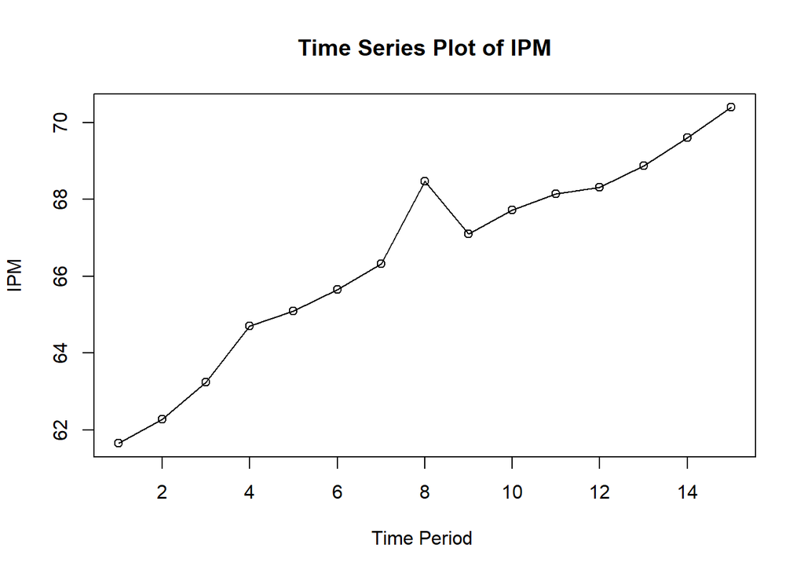

```r
ts.plot(dt.ts, xlab="Time Period ", ylab="IPM", main= "Time Series Plot of IPM")
points(dt.ts)
```

Plot menunjukkan adanya indikasi pola tren pada data sehingga akan dilakukan peramalan dan pemulusan dengan metode DMA dan DES

## Double Moving Average (DMA)

```r
dt.sma <- SMA(dt.ts, n=3)
dma <- SMA(dt.sma, n = 3)
At <- 2*dt.sma - dma
Bt <- 2/(3-1)*(dt.sma - dma)
dt.dma<- At+Bt
dt.ramal<- c(NA, dt.dma)

t = 1:5
f = c()

for (i in t) {
  f[i] = At[length(At)] + Bt[length(Bt)]*(i)
}
```

```r
dt.gab <- cbind(aktual = c(dt.ts,rep(NA,5)),
                pemulusan1 = c(dt.sma,rep(NA,5)),
                pemulusan2 = c(dt.dma, rep(NA,5)),
                At = c(At, rep(NA,5)),
                Bt = c(Bt,rep(NA,5)),
                ramalan = c(dt.ramal, f[-1]))
dt.gab
```

```
##       aktual pemulusan1 pemulusan2       At         Bt  ramalan
##  [1,]  61.65         NA         NA       NA         NA       NA
##  [2,]  62.28         NA         NA       NA         NA       NA
##  [3,]  63.24   62.39000         NA       NA         NA       NA
##  [4,]  64.71   63.41000         NA       NA         NA       NA
##  [5,]  65.09   64.34667   66.27556 65.31111 0.96444444       NA
##  [6,]  65.65   65.15000   66.84556 65.99778 0.84777778 66.27556
##  [7,]  66.32   65.68667   66.93778 66.31222 0.62555556 66.84556
##  [8,]  68.47   66.81333   68.67333 67.74333 0.93000000 66.93778
##  [9,]  67.11   67.30000   68.70000 68.00000 0.70000000 68.67333
## [10,]  67.72   67.76667   68.71333 68.24000 0.47333333 68.70000
## [11,]  68.15   67.66000   67.82889 67.74444 0.08444444 68.71333
## [12,]  68.32   68.06333   68.53000 68.29667 0.23333333 67.82889
## [13,]  68.88   68.45000   69.23444 68.84222 0.39222222 68.53000
## [14,]  69.61   68.93667   69.84333 69.39000 0.45333333 69.23444
## [15,]  70.40   69.63000   70.87889 70.25444 0.62444444 69.84333
## [16,]     NA         NA         NA       NA         NA 70.87889
## [17,]     NA         NA         NA       NA         NA 71.50333
## [18,]     NA         NA         NA       NA         NA 72.12778
## [19,]     NA         NA         NA       NA         NA 72.75222
## [20,]     NA         NA         NA       NA         NA 73.37667
```

### Plot Time Series

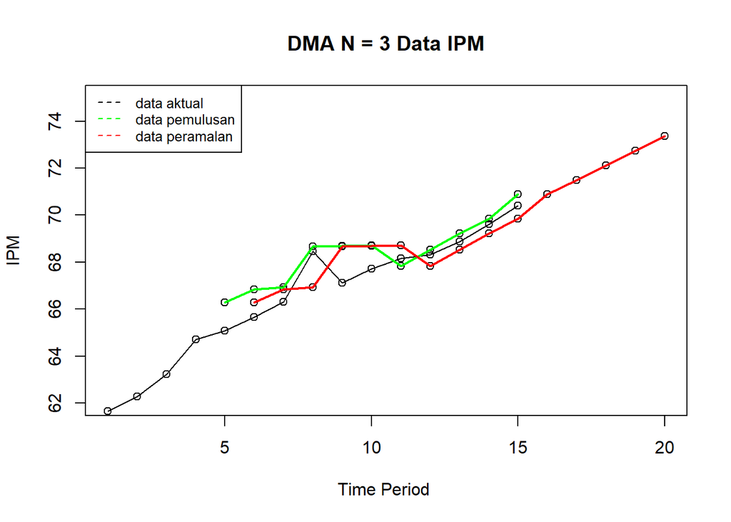

```r
ts.plot(dt.gab[,1], xlab="Time Period ", ylab="IPM",
        main= "DMA N = 3 Data IPM", ylim=c(62,75))
points(dt.gab[,1])
points(dt.gab[,3])
points(dt.gab[,6])
lines(dt.gab[,3],col="green",lwd=2)
lines(dt.gab[,6],col="red",lwd=2)
legend("topleft",c("data aktual","data pemulusan","data peramalan"),
       lty=8, col=c("black","green","red"), cex=0.8)
```

### Akurasi Metode DMA

```r
error.dma = dt.ts-dt.ramal[1:length(dt.ts)]
SSE.dma = sum(error.dma[6:length(dt.ts)]^2)
MSE.dma = mean(error.dma[6:length(dt.ts)]^2)
MAPE.dma = mean(abs((error.dma[6:length(dt.ts)]/dt.ts[6:length(dt.ts)])*100))

akurasi.dma <- matrix(c(SSE.dma, MSE.dma, MAPE.dma))
row.names(akurasi.dma)<- c("SSE", "MSE", "MAPE")
colnames(akurasi.dma) <- c("Akurasi m = 3")
akurasi.dma
```

```
##      Akurasi m = 3
## SSE      7.5515988
## MSE      0.7551599
## MAPE     1.1143574
```

Didapatkan error paling kecil sebesar 0,75 berdasarkan MSE sehingga dapat dikatakan bahwa model sangat baik

## Double Exponential Smoothing (DES)

### Pembagian Data

```r
training<-data[1:10,2]
testing<-data[11:15,2]

training.ts<-ts(training)
testing.ts<-ts(testing,start=11)
```

### Plot Data Training

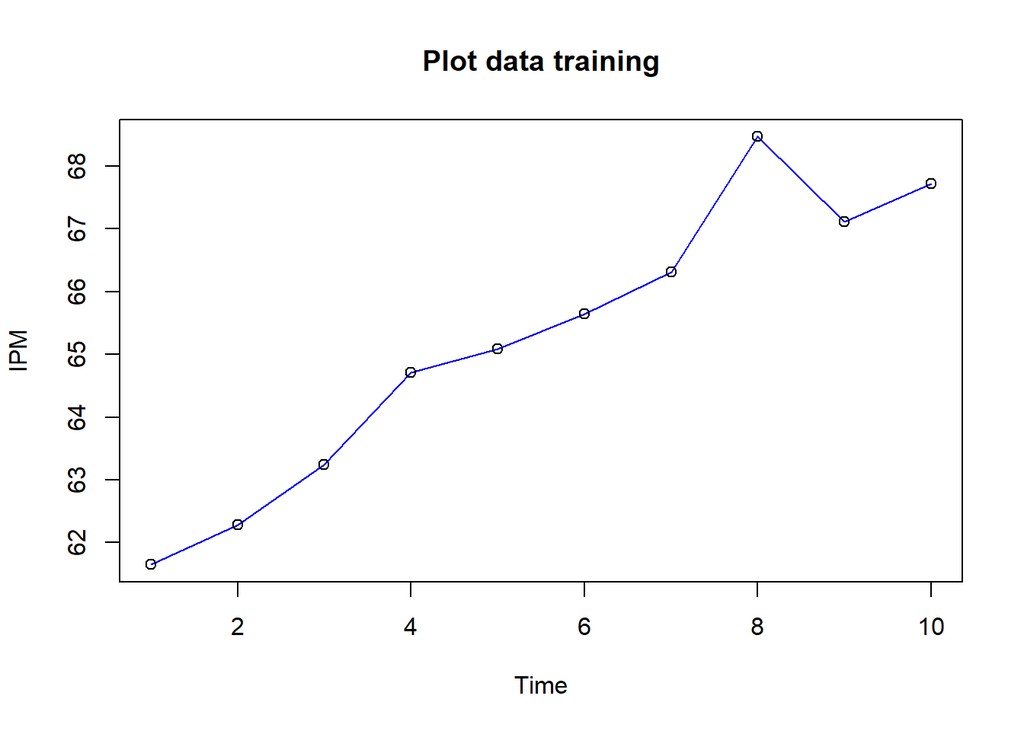

```r
plot(training.ts, col="blue",main="Plot data training")
points(training.ts)
```

### Plot Data Testing

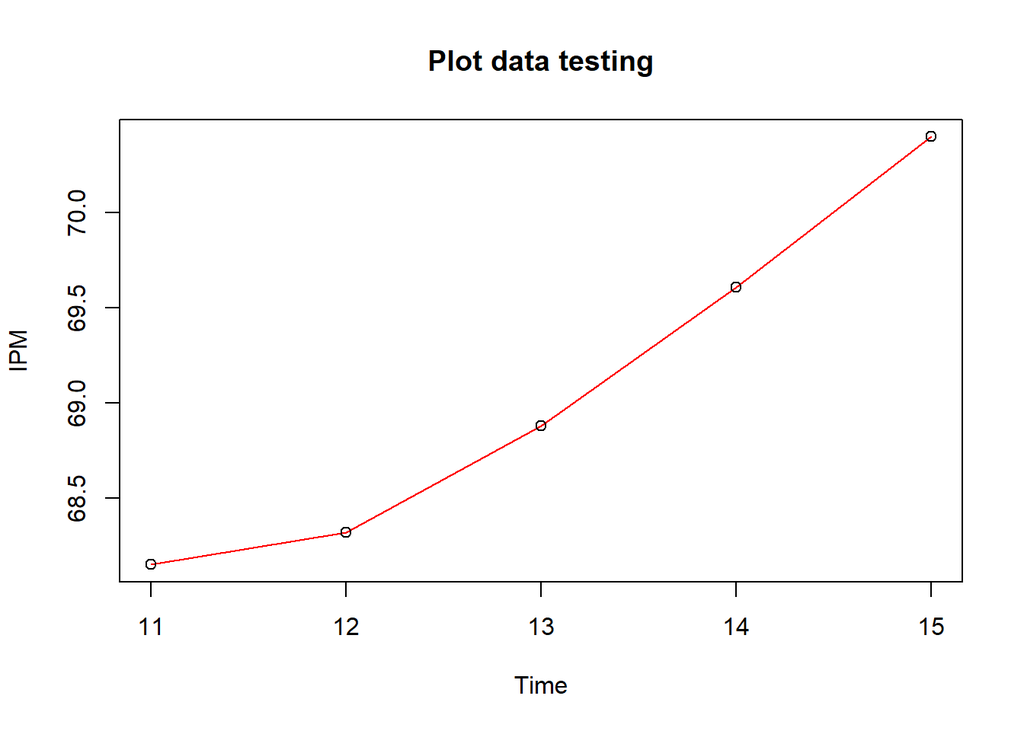

```r
plot(testing.ts, col="red",main="Plot data testing")
points(testing.ts)
```

### DES dengan Lamda & Gamma Optimum

```r
des.opt<- HoltWinters(training.ts, gamma = FALSE)
des.opt
```

```
## Holt-Winters exponential smoothing with trend and without seasonal component.
##
## Call:
## HoltWinters(x = training.ts, gamma = FALSE)
##
## Smoothing parameters:
##  alpha: 0.3937804
##  beta : 0
##  gamma: FALSE
##
## Coefficients:
##       [,1]
## a 68.10626
## b  0.63000
```

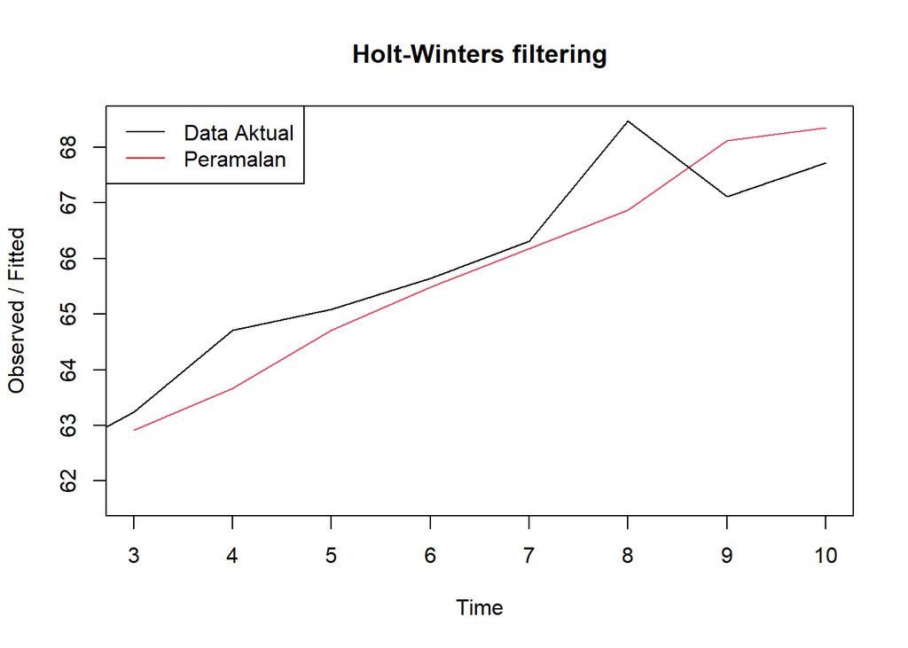

```r
plot(des.opt)
legend("topleft", c("Data Aktual", "Peramalan"), col = c("black", "red"),
       lty = c(1,1))
```

```r
ramalandesopt<- forecast(des.opt, h=7)
ramalandesopt
```

```
##    Point Forecast    Lo 80    Hi 80    Lo 95    Hi 95
## 11       68.73626 67.66462 69.80790 67.09733 70.37520
## 12       69.36626 68.21453 70.51800 67.60483 71.12769
## 13       69.99626 68.76965 71.22287 68.12032 71.87220
## 14       70.62626 69.32909 71.92343 68.64241 72.61011
## 15       71.25626 69.89218 72.62034 69.17008 73.34245
## 16       71.88626 70.45840 73.31413 69.70253 74.06999
## 17       72.51626 71.02734 74.00518 70.23916 74.79336
```

### Akurasi Metode DES

#### Akurasi Data Training

```r
ssedes.train<-des.opt$SSE
msedes.train<-ssedes.train/length(training.ts)
sisaandes<-ramalandesopt$residuals
head(sisaandes)
```

```
## Time Series:
## Start = 1
## End = 6
## Frequency = 1
##              x
## [1,]        NA
## [2,]        NA
## [3,] 0.3300000
## [4,] 1.0400525
## [5,] 0.3805002
## [6,] 0.1606667
```

```r
mapedes.train <- sum(abs(sisaandes[3:length(training.ts)]/training.ts[3:length(training.ts)])*100)/length(training.ts)

akurasides.opt <- matrix(c(ssedes.train,msedes.train,mapedes.train))
row.names(akurasides.opt)<- c("SSE", "MSE", "MAPE")
colnames(akurasides.opt) <- c("Akurasi lamda dan gamma optimum")
akurasides.opt
```

```
##      Akurasi lamda dan gamma optimum
## SSE                        5.3930397
## MSE                        0.5393040
## MAPE                       0.7965026
```

#### Akurasi Data Testing

```r
selisihdesopt<-ramalandesopt$mean-testing.ts
selisihdesopt
```

```
## Time Series:
## Start = 11
## End = 15
## Frequency = 1
##      testing.ts
## [1,]  0.5862606
## [2,]  1.0462606
## [3,]  1.1162606
## [4,]  1.0162606
## [5,]  0.8562606
```

```r
SSEtestingdesopt<-sum(selisihdesopt^2)
SSEtestingdesopt<-SSEtestingdesopt/length(testing.ts)
MAPEtestingdesopt<-sum(abs(selisihdesopt/testing.ts)*100)/length(testing.ts)

akurasiDesTesting <- matrix(c(SSEtestingdesopt,SSEtestingdesopt,MAPEtestingdesopt))
row.names(akurasiDesTesting)<- c("SSE", "MSE", "MAPE")
colnames(akurasiDesTesting) <- c("Akurasi lamda dan gamma optimum")
akurasiDesTesting
```

```
##      Akurasi lamda dan gamma optimum
## SSE                        0.8900737
## MSE                        0.8900737
## MAPE                       1.3376928
```

### Perbandingan Akurasi Metode DMA dengan DES

```r
cbind(akurasi.dma, akurasides.opt)
```

```
##      Akurasi m = 3 Akurasi lamda dan gamma optimum
## SSE      7.5515988                       5.3930397
## MSE      0.7551599                       0.5393040
## MAPE     1.1143574                       0.7965026
```

Berdasarkan perbandingan akurasi tersebut, terlihat nilai SSE, MSE, dan MAPE metode DES lebih kecil dibandingkan dengan metode DMA. Oleh karena itu, metode peramalan dan pemulusan yang terbaik antara keduanya adalah dengan metode DES.

## Eksplorasi dengan Scatter Plot

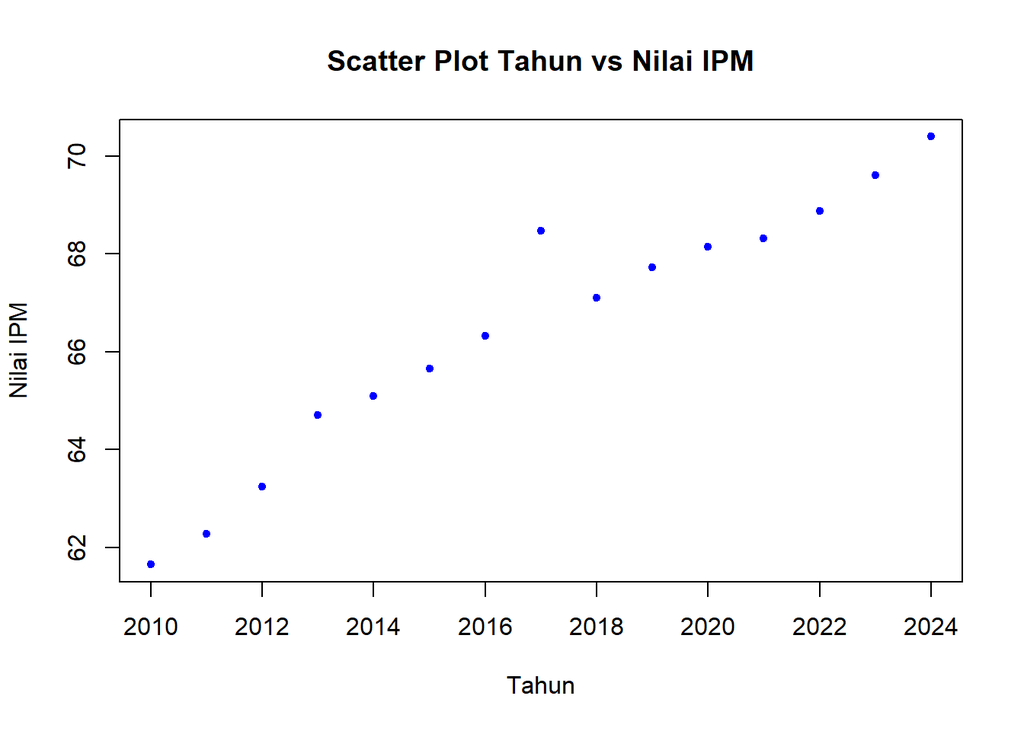

```r
plot(data$Tahun, data$IPM, pch = 20, col = "blue",
     main = "Scatter Plot Tahun vs Nilai IPM",
     xlab = "Tahun",
     ylab = "Nilai IPM")
```

## Nilai Korelasi

```r
cor(data$Tahun, data$IPM)
```

```
## [1] 0.9669153
```

Berdasarkan scatter plot di atas terlihat adanya hubungan / korelasi positif antara peubah tahun dengan nilai IPM, terlihat titik-titik pada plot yang naik ke arah kanan atas. Hal tersebut juga diperkuat dengan hasil perhitungan aplikasi R di mana didapatkan nilai korelasi sebesar **0,9669153**.

# Pemodelan Regresi

```r
model<- lm(IPM~Tahun, data = data)
summary(model)
```

```
##
## Call:
## lm(formula = IPM ~ Tahun, data = data)
##
## Residuals:
##      Min       1Q   Median       3Q      Max
## -0.80717 -0.43742 -0.09217  0.30958  1.96333
##
## Coefficients:
##               Estimate Std. Error t value Pr(>|t|)
## (Intercept) -1.100e+03  8.538e+01  -12.89 8.84e-09 ***
## Tahun        5.785e-01  4.233e-02   13.67 4.33e-09 ***
## ---
## Signif. codes:  0 '***' 0.001 '**' 0.01 '*' 0.05 '.' 0.1 ' ' 1
##
## Residual standard error: 0.7083 on 13 degrees of freedom
## Multiple R-squared:  0.9349, Adjusted R-squared:  0.9299
## F-statistic: 186.8 on 1 and 13 DF,  p-value: 4.329e-09
```

Didapatkan model regresi dengan persamaan
$$y_i = -1100 + 0,5785 x_t$$
Berdasarkan ringkasan model dapat diketahui bahwa hasil uji F memiliki p-value < α (5%). Artinya, minimal terdapat satu variabel yang berpengaruh nyata terhadap model. Hasil uji-t parsial kedua parameter regresi, yaitu intersep dan koefisien regresi juga menunjukkan hal yang sama, yaitu memiliki p-value < α (5%) sehingga nyata dalam taraf 5%. Selanjutnya dapat dilihat juga nilai $R^2 = 0.9349$. Artinya, sebesar 93,49% keragaman nilai IPM dapat dijelaskan oleh peubah tahun. Hasil ini menunjukkan hasil yang dapat dikatakan sangat baik Namun, diperlukan juga melakukan uji terhadap sisaannya.

# Uji Normalitas dan Autokrelasi

## Secara Eksploratif

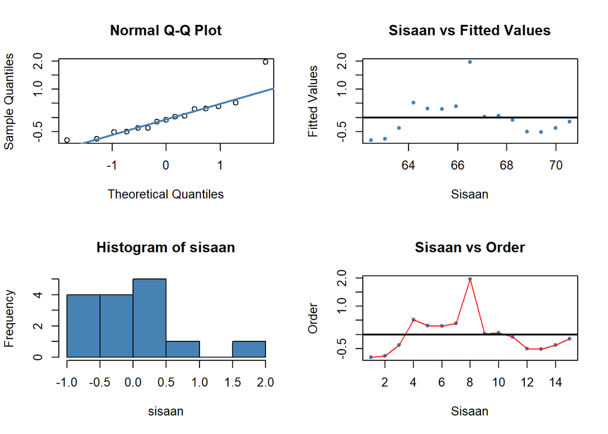

```r
#sisaan dan fitted value
sisaan<- residuals(model)
fitValue<- predict(model)

#Diagnostik dengan eksploratif
par(mfrow = c(2,2))
qqnorm(sisaan)
qqline(sisaan, col = "steelblue", lwd = 2)
plot(fitValue, sisaan, col = "steelblue", pch = 20, xlab = "Sisaan", ylab = "Fitted Values", main = "Sisaan vs Fitted Values")
abline(a = 0, b = 0, lwd = 2)
hist(sisaan, col = "steelblue")
plot(seq(1,15,1), sisaan, col = "steelblue", pch = 20, xlab = "Sisaan", ylab = "Order", main = "Sisaan vs Order")
lines(seq(1,15,1), sisaan, col = "red")
abline(a = 0, b = 0, lwd = 2)
```

Berdasarkan Normal QQ Plot, sisaan cenderung menyebar normal, tetapi histogram dari sisaan tidak menunjukkan demikian. Plot Sisaan vs Fitted Value dan Plot Sisaan vs Order menunjukkan adanya pola pada sisaan sehingga dapat dikatakan ada indikasi autokorelasi. Untuk lebih lanjut akan digunakan uji formal melihat normalitas sisaan dan plot ACF dan PACF untuk melihat apakah ada autokorelasi atau tidak.

## Uji Formal

**Hipotesis asumsi normalitas**

$H_0$: sisaan mengikuti sebaran normal

$H_1$: sisaan tidak mengikuti sebaran normal

```r
shapiro.test(sisaan)
```

```
##
##  Shapiro-Wilk normality test
##
## data:  sisaan
## W = 0.85784, p-value = 0.02246
```

```r
ks.test(sisaan, "pnorm", mean=mean(sisaan), sd=sd(sisaan))
```

```
##
##  Exact one-sample Kolmogorov-Smirnov test
##
## data:  sisaan
## D = 0.15758, p-value = 0.7965
## alternative hypothesis: two-sided
```

Berdasarkan uji formal Saphiro-Wilk didapatkan nilai p-value < α (5%), sementara uji formal Kolmogorov-Smirnov didapatkan nilai p-value > α (5%).

**Hipotesis asumsi autokorelasi**

$H_0$: tidak ada autokorelasi

$H_1$: ada autokorelasi

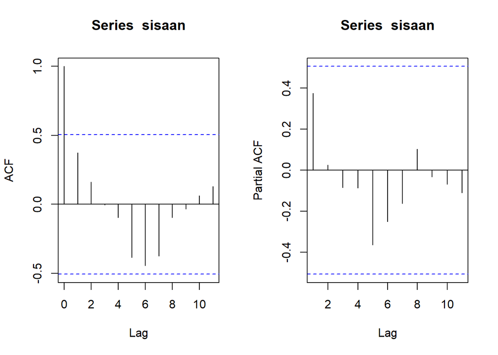

```r
#ACF dan PACF identifikasi autokorelasi
par(mfrow = c(1,2))
acf(sisaan)
pacf(sisaan)
```

Berdasarkan plot ACF dan PACF, terlihat semua dalam rentang batas dan tidak ada lag yang signifikan. Namun, untuk lebih memastikan akan dilakukan uji formal dengan uji Durbin Watson.

```r
dwtest(model)
```

```
##
##  Durbin-Watson test
##
## data:  model
## DW = 1.1463, p-value = 0.01629
## alternative hypothesis: true autocorrelation is greater than 0
```

Dengan nilai p-value < 0.05 dapat disimpulkan bahwa tolak $H_0$, cukup bukti mengatakan adanya autokorelasi. Oleh karena itu, diperlukan penangan autokorelasi. Penanganan yang akan digunakan menggunakan dua metode, yaitu Cochrane-Orcutt dan Hildret-Lu.

# Penanganan Autokorelasi

## Metode Cochrane-Orcutt

```r
modelCO<-cochrane.orcutt(model)
modelCO
```

```
## Cochrane-orcutt estimation for first order autocorrelation
##
## Call:
## lm(formula = IPM ~ Tahun, data = data)
##
##  number of interaction: 8
##  rho 0.380316
##
## Durbin-Watson statistic
## (original):    1.14629 , p-value: 1.629e-02
## (transformed): 2.24940 , p-value: 5.637e-01
##
##  coefficients:
##  (Intercept)        Tahun
## -1007.205175     0.532399
```

Didapatkan model regresi dengan persamaan
$$y_i = -1007,205175 + 0,532399 x_t$$
Hasil juga menunjukkan bahwa nilai DW dan p-value meningkat menjadi **2,24940** dan **0,5637**. Nilai p-value > 0.05 menunjukkan bahwa belum cukup bukti menyatakan bahwa sisaan terdapat autokorelasi pada taraf nyata 5%. Untuk nilai $\hat{\rho}$ optimum yang digunakan adalah **0,380316**.

```r
# Rho optimum
rho <- modelCO$rho
rho
```

```
## [1] 0.3803156
```

Selanjutnya akan dilakukan transformasi secara manual dengan syntax berikut ini.

```r
data$IPM
```

```
##  [1] 61.65 62.28 63.24 64.71 65.09 65.65 66.32 68.47 67.11 67.72 68.15 68.32
## [13] 68.88 69.61 70.40
```

```r
data$IPM[-1]
```

```
##  [1] 62.28 63.24 64.71 65.09 65.65 66.32 68.47 67.11 67.72 68.15 68.32 68.88
## [13] 69.61 70.40
```

```r
# Transformasi Manual
ipm.trans<- data$IPM[-1]-data$IPM[-12]*rho
tahun.trans<- data$Tahun[-1]-data$Tahun[-12]*rho
modelCOmanual<- lm(ipm.trans~tahun.trans)
summary(modelCOmanual)
```

```
##
## Call:
## lm(formula = ipm.trans ~ tahun.trans)
##
## Residuals:
##      Min       1Q   Median       3Q      Max
## -0.74519 -0.28872 -0.05190  0.05714  1.75817
##
## Coefficients:
##              Estimate Std. Error t value Pr(>|t|)
## (Intercept) -615.5963    87.7834  -7.013 1.41e-05 ***
## tahun.trans    0.5255     0.0702   7.487 7.36e-06 ***
## ---
## Signif. codes:  0 '***' 0.001 '**' 0.01 '*' 0.05 '.' 0.1 ' ' 1
##
## Residual standard error: 0.6276 on 12 degrees of freedom
## Multiple R-squared:  0.8237, Adjusted R-squared:  0.809
## F-statistic: 56.05 on 1 and 12 DF,  p-value: 7.364e-06
```

```r
#Mencari Penduga Koefisien Regresi setelah Transformasi ke Persamaan Awal
b0bintang <- modelCOmanual$coefficients[-2]
b0 <- b0bintang/(1-rho)
b1 <- modelCOmanual$coefficients[-1]
b0
```

```
## (Intercept)
##   -993.4029
```

```r
b1
```

```
## tahun.trans
##   0.5255492
```

Sehingga didapatkan model regresi dengan persamaan
$$y_i = -993.4029 + 0.5255492 x_t$$

## Metode Hildreth-Lu

```r
hildreth.lu.func<- function(r, model){
  x <- model.matrix(model)[,-1]
  y <- model.response(model.frame(model))
  n <- length(y)
  t <- 2:n
  y <- y[t]-r*y[t-1]
  x <- x[t]-r*x[t-1]

  return(lm(y~x))
}

#Pencariab rho yang meminimumkan SSE
r <- c(seq(0.1,0.9, by= 0.1))
tab <- data.frame("rho" = r, "SSE" = sapply(r, function(i){deviance(hildreth.lu.func(i, model))}))
round(tab, 4)
```

```
##   rho    SSE
## 1 0.1 5.2344
## 2 0.2 4.9354
## 3 0.3 4.7663
## 4 0.4 4.7269
## 5 0.5 4.8174
## 6 0.6 5.0376
## 7 0.7 5.3877
## 8 0.8 5.8676
## 9 0.9 6.4772
```

Pada hasil di atas terlihat $\rho$ minimum ketika 0,4. Namun, hasil tersebut masih kurang teliti sehingga akan dicari kembali $\rho$ yang lebih optimum dengan ketelitian yang lebih. Jika sebelumnya jarak antar $\rho$ yang dicari adalah 0,1, kali ini jarak antar $\rho$ adalah 0,001 dan dilakukan pada selang 0,2 sampai dengan 0,5.

```r
#Rho optimal di sekitar 0.4
rOpt <- seq(0.2,0.5, by= 0.001)
tabOpt <- data.frame("rho" = rOpt, "SSE" = sapply(rOpt, function(i){deviance(hildreth.lu.func(i, model))}))
head(tabOpt[order(tabOpt$SSE),])
```

```
##       rho      SSE
## 181 0.380 4.724425
## 182 0.381 4.724428
## 180 0.379 4.724436
## 183 0.382 4.724443
## 179 0.378 4.724460
## 184 0.383 4.724471
```

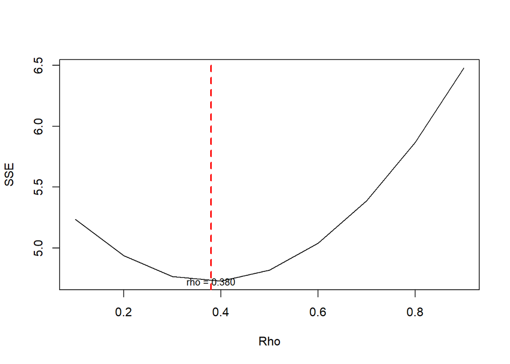

```r
#Grafik SSE optimum
par(mfrow = c(1,1))
plot(tab$SSE ~ tab$rho , type = "l", xlab = "Rho", ylab = "SSE")
abline(v = tabOpt[tabOpt$SSE==min(tabOpt$SSE),"rho"], lty = 2, col="red",lwd=2)
text(x = 0.380  , y = 4.724425  , labels = "rho = 0.380", cex = 0.8)
```

```r
#Model terbaik
modelHL <- hildreth.lu.func(0.341, model)
summary(modelHL)
```

```
##
## Call:
## lm(formula = y ~ x)
##
## Residuals:
##      Min       1Q   Median       3Q      Max
## -0.71865 -0.31342 -0.04959  0.09151  1.76168
##
## Coefficients:
##               Estimate Std. Error t value Pr(>|t|)
## (Intercept) -667.82016   84.03874  -7.947 4.03e-06 ***
## x              0.53546    0.06319   8.473 2.08e-06 ***
## ---
## Signif. codes:  0 '***' 0.001 '**' 0.01 '*' 0.05 '.' 0.1 ' ' 1
##
## Residual standard error: 0.6281 on 12 degrees of freedom
## Multiple R-squared:  0.8568, Adjusted R-squared:  0.8449
## F-statistic:  71.8 on 1 and 12 DF,  p-value: 2.077e-06
```

```r
#Transformasi Balik
cat("y = ", coef(modelHL)[1]/(1-0.341), "+", coef(modelHL)[2],"x", sep = "")
```

```
## y = -1013.384+0.5354568x
```

Sehingga didapatkan model regresi dengan persamaan
$$y_i = -1013.384 + 0.5354568 x_t$$

```r
#Deteksi autokorelasi
dwtest(modelHL)
```

```
##
##  Durbin-Watson test
##
## data:  modelHL
## DW = 2.1556, p-value = 0.4906
## alternative hypothesis: true autocorrelation is greater than 0
```

```r
# Perbandingan
sseModelawal <- anova(model)$`Sum Sq`[-1]
sseModelCO <- anova(modelCOmanual)$`Sum Sq`[-1]
sseModelHL <- anova(modelHL)$`Sum Sq`[-1]
mseModelawal <- sseModelawal/length(data$IPM)
mseModelCO <- sseModelCO/length(data$IPM)
mseModelHL <- sseModelHL/length(data$IPM)
akurasi <- matrix(c(sseModelawal,sseModelCO,sseModelHL,
                    mseModelawal,mseModelCO,mseModelHL),nrow=2,ncol=3,byrow = T)
colnames(akurasi) <- c("Model Awal", "Model Cochrane-Orcutt", "Model Hildreth-Lu")
row.names(akurasi) <- c("SSE","MSE")
akurasi
```

```
##     Model Awal Model Cochrane-Orcutt Model Hildreth-Lu
## SSE  6.5223033             4.7262250         4.7344566
## MSE  0.4348202             0.3150817         0.3156304
```

Berdasarkan hasil tersebut dapat diketahui bahwa hasil penanganan autokorelasi dengan metode Cochrane-Orcutt dan Hildreth-Lu memiliki SSE dan MSE yang tidak jauh berbeda dan juga lebih baik dibandingkan model awal ketika autokorelasi masih terjadi.

# Kesimpulan